# Portfolio assignment 11

20 min: Do a Numerical VS Categorical bivariate analysis on the penguins dataset.

- Choose one of the categorical columns: species, island or sex
- use .groupby('').mean() too look at the means of the numerical columns. Does it look like there is a difference between categories?
- Use the seaborn barplot to plot the mean and confidence. Create this plot for each of the numerical columns (bill_length_mm bill_depth_mm, flipper_length_mm, body_mass_g)
- For each of the plots, write a conclusion: Is there a statistically significant difference for this numerical column for each category?
- Optional: Repeat this proces for the other two categorical columns

```python
import pandas as pd
import seaborn as sns
import scipy.stats as st
```

```python
sns.set_theme(style="whitegrid")
```

```python
penguin = sns.load_dataset("penguins")
```

```python
penguin.head()
```

|  | species | island | bill_length_mm | bill_depth_mm | flipper_length_mm | body_mass_g | sex |
| --- | --- | --- | --- | --- | --- | --- | --- |
| 0 | Adelie | Torgersen | 39.1 | 18.7 | 181.0 | 3750.0 | Male |
| 1 | Adelie | Torgersen | 39.5 | 17.4 | 186.0 | 3800.0 | Female |
| 2 | Adelie | Torgersen | 40.3 | 18.0 | 195.0 | 3250.0 | Female |
| 3 | Adelie | Torgersen | NaN | NaN | NaN | NaN | NaN |
| 4 | Adelie | Torgersen | 36.7 | 19.3 | 193.0 | 3450.0 | Female |

```python
penguin.groupby("species").mean()
```

| species | bill_length_mm | bill_depth_mm | flipper_length_mm | body_mass_g |
| --- | --- | --- | --- | --- |
| Adelie | 38.791391 | 18.346358 | 189.953642 | 3700.662252 |
| Chinstrap | 48.833824 | 18.420588 | 195.823529 | 3733.088235 |
| Gentoo | 47.504878 | 14.982114 | 217.186992 | 5076.016260 |

## Species vs Numerical

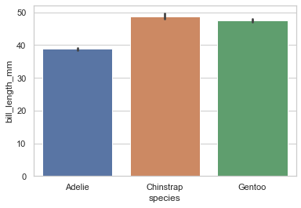

```python
sns.barplot(y="bill_length_mm", x="species", data=penguin)
# Add parameter ci if you want to change certainty of confidence interval.
# For example ci = 99 for 99% certainty.
# The default is 95%
```

#### Op basis van deze gegevens kunnen we conluderen dat er een verschil is in bek lengte tussen de Adelie en Chinstrap of Gentoo soort. De Chinstrap en Gentoo soorten overlappen in confidence interval. Hierdoor kunnen we niet zeggen dat deze van elkaar verschillen of gelijk zijn.

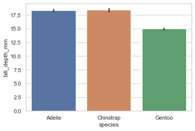

```python
sns.barplot(y="bill_depth_mm", x="species", data=penguin)
```

#### Op basis van deze gegevens kunnen we concluderen dat er een verschil in de diepte van de bek tussen de Gentoo en Chinstrap of Adelie soort is. De Adelie en Chinstrap soort overlappen in confidence interval. Hierdoor kunnen we concluderen dat er niet een duidelijk verschil is tussen deze twee soorten wat betreft de bek diepte. Dit geeft alleen ook niet aan dat ze hetzelfde zijn.

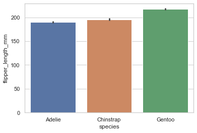

```python
sns.barplot(y="flipper_length_mm", x="species", data=penguin)
```

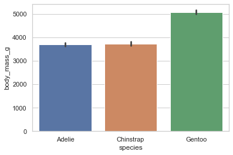

```python
sns.barplot(y="body_mass_g", x="species", data=penguin)
```

#### Op basis van deze gegevens kunnen we concluderen dat er een verschil in gewicht tussen de Gentoo en Chinstrap of Adelie soort is. De Adelie en Chinstrap soort overlappen in confidence interval. Hierdoor kunnen we concluderen dat er niet een duidelijk verschil is tussen deze twee soorten wat betreft gewicht. Dit geeft alleen ook niet aan dat ze hetzelfde zijn.

## Island vs Numerical

```python
penguin.groupby("island").mean()
```

| island | bill_length_mm | bill_depth_mm | flipper_length_mm | body_mass_g |
| --- | --- | --- | --- | --- |
| Biscoe | 45.257485 | 15.874850 | 209.706587 | 4716.017964 |
| Dream | 44.167742 | 18.344355 | 193.072581 | 3712.903226 |
| Torgersen | 38.950980 | 18.429412 | 191.196078 | 3706.372549 |

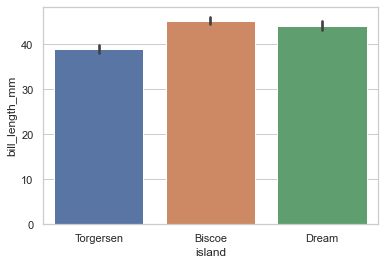

```python
sns.barplot(y="bill_length_mm", x="island", data=penguin)
```

#### Op basis van deze gegevens kunnen we concluderen dat er een verschil is in de lengte van de bek tussen penguins op Torgersen en Biscoe of Dream. De penguins op Biscoe en Dream overlappen in confidence interval. Hierdoor kunnen we concluderen dat er niet een duidelijk verschil is tussen de bek lengte van de penguins op deze twee eilanden. Dit geeft alleen ook niet aan dat ze hetzelfde zijn.

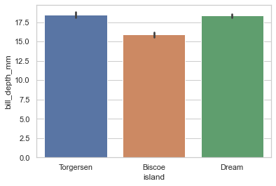

```python
sns.barplot(y="bill_depth_mm", x="island", data=penguin)
```

#### Op basis van deze gegevens kunnen we concluderen dat er een verschil is in de diepte van de bek tussen penguins op Biscoe en Togersen of Dream. De penguins op Torgersen en Dream overlappen in confidence interval. Hierdoor kunnen we concluderen dat er niet een duidelijk verschil is tussen de diepte van de bek van penguins op deze twee eilanden. Dit geeft alleen ook niet aan dat ze hetzelfde zijn.

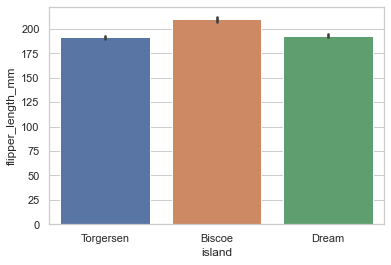

```python
sns.barplot(y="flipper_length_mm", x="island", data=penguin)
```

#### Op basis van deze gegevens kunnen we concluderen dat er een verschil is in de flipper lengte tussen penguins op Biscoe en Torgersen of Dream. De penguins op Togersen en Dream overlappen in confidence interval. Hierdoor kunnen we concluderen dat er niet een duidelijk verschil is tussen de flipper lengte van de penguins op deze twee eilanden. Dit geeft alleen ook niet aan dat ze hetzelfde zijn.

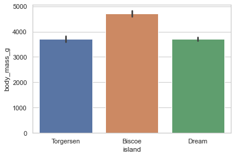

```python
sns.barplot(y="body_mass_g", x="island", data=penguin)
```

#### Op basis van deze gegevens kunnen we concluderen dat er een verschil is in gewicht tussen penguins op Biscoe en Torgersen of Dream. De penguins op Torgersen en Dream overlappen in confidence interval. Hierdoor kunnen we concluderen dat er niet een duidelijk verschil is tussen het gewicht van de penguins op deze twee eilanden. Dit geeft alleen ook niet aan dat ze hetzelfde zijn.

## Sex vs Numerical

```python
penguin.groupby("sex").mean()
```

| sex | bill_length_mm | bill_depth_mm | flipper_length_mm | body_mass_g |
| --- | --- | --- | --- | --- |
| Female | 42.096970 | 16.425455 | 197.363636 | 3862.272727 |
| Male | 45.854762 | 17.891071 | 204.505952 | 4545.684524 |

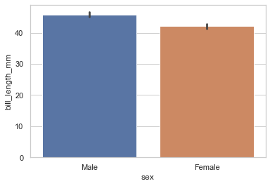

```python
sns.barplot(y="bill_length_mm", x="sex", data=penguin)
```

#### Op basis van deze gegevens kunnen we concluderen dat er een verschil is in bek lengte tussen mannetjes en vrouwtjes penguins.

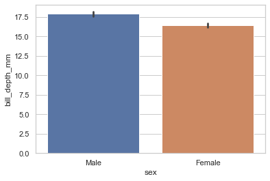

```python
sns.barplot(y="bill_depth_mm", x="sex", data=penguin)
```

#### Op basis van deze gegevens kunnen we concluderen dat er een verschil is in bek diepte tussen mannetjes en vrouwtjes penguins.

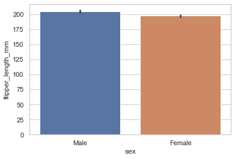

```python
sns.barplot(y="flipper_length_mm", x="sex", data=penguin)
```

#### Op basis van deze gegevens kunnen we concluderen dat er een verschil is in flipper lengte tussen mannetjes en vrouwtjes penguins.

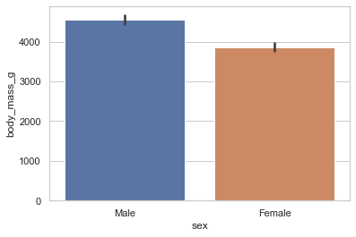

```python
sns.barplot(y="body_mass_g", x="sex", data=penguin)
```

#### Op basis van deze gegevens kunnen we concluderen dat er een verschil is in gewicht tussen mannetjes en vrouwtjes penguins.